# Novavax UK 302

### Marker set

Immune markers come from several studies. In addition to the samples collected to study the correlates, the database contains antibody measurements from a separate immunogenicity study and a flu study. We will only use the samples collected for the correlates study because 1) we don’t know if we can compute sampling probabilities for the other samples, 2) to avoid potential batch effects because samples for different studies were run at different times, and 3) 17 out of 19 cases with markers are in this set. Hence, we define SubcohortIn as 3.Case + 3.Control and that is what we will use for our correlates study.

```r
with(subset(dat_mapped, EarlyinfectionD35==0 & Perprotocol==1 & Bserostatus==0 & Trt==1), mytable(SampleSet, EventIndPrimaryD35))
```

```
##            EventIndPrimaryD35
## SampleSet      0    1 <NA>
##   1          464    0    2
##   2          183    2    1
##   3.Case       1   17    0
##   3.Control   67    0    1
##   <NA>      6076    2  110
```

There is one ptid in 3.Case in the table above, whose AnyinfectionD1 is 1 and EventIndPrimaryD1 is 0. They are not a case by a stringent criterion but is by a relaxed criterion.

```r
subset(dat_mapped, EarlyinfectionD35==0 & Perprotocol==1 & Bserostatus==0 & Trt==1 & EventIndPrimaryD35==0 & SampleSet=="3.Case", select=c(Subjectid, AnyinfectionD1, EventIndPrimaryD1))
```

```
##                     Subjectid AnyinfectionD1 EventIndPrimaryD1
## 7043 NVX2019NCOV302-UK0170240              1                 0
```

There are also 16 ptids without markrs whose AnyinfectionD1 is 1 and EventIndPrimaryD1 is 0. **We will exclude all such ptids from ph1.D35.**

```r
with(subset(dat_mapped, EarlyinfectionD35==0 & Perprotocol==1 & Bserostatus==0 & Trt==1 & AnyinfectionD1==1 & EventIndPrimaryD1==0), mytable( SubcohortInd))
```

```
## SubcohortInd
##  0  1
## 16  1
```

In the analysis data, the one ptid within 3.case and with EventIndPrimaryD35==0 has been filtered out.

```r
with(subset(dat_proc, ph1.D35 & Bserostatus==0 & Trt==1), mytable(SampleSet, EventIndPrimaryD35))
```

```
##            EventIndPrimaryD35
## SampleSet      0    1
##   1          462    0
##   2          182    2
##   3.Case       0   17
##   3.Control   67    0
##   <NA>      6007    2
```

### Marker data

```r
10**sort(unique(dat_mapped$BbindNVXIgG))[1:10]
```

```
##  [1] 500 521 537 545 570 575 576 585 602 626
```

Correlation plot between baseline and D35 marker suggests that under 1000 (antilog scale), the values are non-specific.

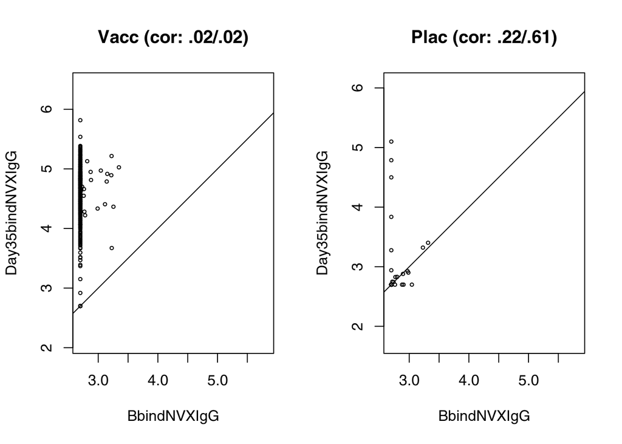

```r
par(mfrow=c(1,2))
lim=range(dat_mapped$Day35bindNVXIgG, na.rm=T)
corplot(Day35bindNVXIgG~BbindNVXIgG, dat_mapped[dat_mapped$Trt==1,], xlim=lim, asp=1, main="Vacc")
corplot(Day35bindNVXIgG~BbindNVXIgG, dat_mapped[dat_mapped$Trt==0,], xlim=lim, asp=1, main="Plac")
```

This does not matter too much for our study because only a few ptids are in that range in the vaccine arm:

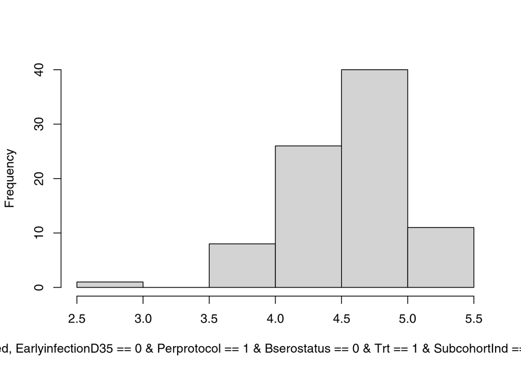

```r
hist(subset(dat_mapped, EarlyinfectionD35==0 & Perprotocol==1 & Bserostatus==0 & Trt==1 & SubcohortInd==1)$Day35bindNVXIgG, main="")
```

Marker is higher in the young people than the old people.

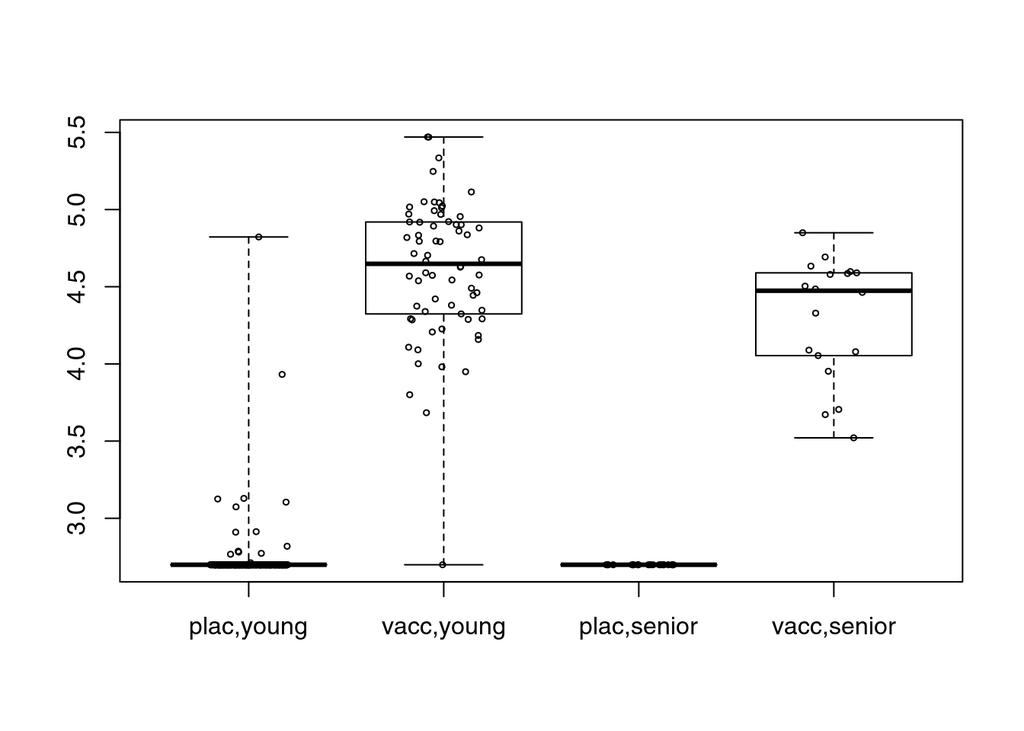

```r
myboxplot(Day35bindNVXIgG~Trt+Senior, subset(dat_proc, ph2.D35==1), names=c("plac,young","vacc,young","plac,senior","vacc,senior"))
```

```r
# with(subset(dat_proc, ph2.D35==1), mytable(Trt, Day35bindNVXIgGcat))
```

Two sample test comparing marker between England South East and England Other is not significant, but there is a trend.

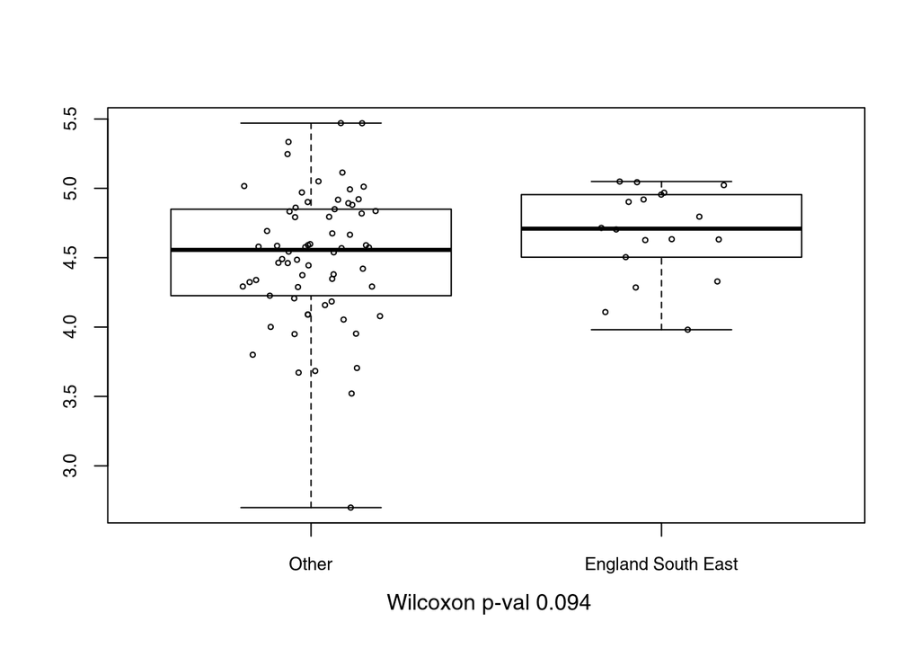

```r
myboxplot(Day35bindNVXIgG~Region1, subset(dat_proc, ph2.D35==1 & Trt==1), cex.axis=0.8, test="w", names=c("Other","England South East"))
```

```r
wilcox.test(Day35bindNVXIgG~Region, subset(dat_proc, ph2.D35==1 & Trt==1 & Region!="Scotland, Wales, Northern Ireland"))
```

```
##
##  Wilcoxon rank sum test with continuity correction
##
## data:  Day35bindNVXIgG by Region
## W = 356, p-value = 0.1341
## alternative hypothesis: true location shift is not equal to 0
```

### Covariates adjustment

Age is a risk factor in placebo but not vaccine. Southeast England (London) is a risk factror in placebo but not vaccine. Both could be due to the number of cases is much smaller in the vaccine arm. Test of interaction is not significant. In both arms together, they are significant. We decide to adjust for both Senior (age>=65) and Southeast England because **they are both confounders**. Younger people and London both have higher risk and higher markers. We adjust for Senior instead of age because the relationship between age and risk is complicated.

```r
coxph(Surv(EventTimePrimaryD35,EventIndPrimaryD35)~Region+Age+Sex, subset(dat_proc, ph1.D35==1 & Trt==0))
```

```
## Call:
## coxph(formula = Surv(EventTimePrimaryD35, EventIndPrimaryD35) ~
##     Region + Age + Sex, data = subset(dat_proc, ph1.D35 == 1 &
##     Trt == 0))
##
##                                              coef exp(coef)  se(coef)      z
## RegionEngland South East                 0.838491  2.312874  0.221102  3.792
## RegionScotland, Wales, Northern Ireland -0.045821  0.955213  0.337524 -0.136
## Age                                     -0.025403  0.974916  0.006849 -3.709
## Sex                                      0.015118  1.015232  0.206016  0.073
##                                                p
## RegionEngland South East                0.000149
## RegionScotland, Wales, Northern Ireland 0.892013
## Age                                     0.000208
## Sex                                     0.941503
##
## Likelihood ratio test=33.15  on 4 df, p=1.115e-06
## n= 6640, number of events= 95
```

```r
coxph(Surv(EventTimePrimaryD35,EventIndPrimaryD35)~Region+Age+Sex, subset(dat_proc, ph1.D35==1 & Trt==1))
```

```
## Call:
## coxph(formula = Surv(EventTimePrimaryD35, EventIndPrimaryD35) ~
##     Region + Age + Sex, data = subset(dat_proc, ph1.D35 == 1 &
##     Trt == 1))
##
##                                             coef exp(coef) se(coef)      z
## RegionEngland South East                 0.42581   1.53082  0.48122  0.885
## RegionScotland, Wales, Northern Ireland -0.40575   0.66648  0.76469 -0.531
## Age                                     -0.01754   0.98261  0.01501 -1.168
## Sex                                     -0.36737   0.69255  0.44955 -0.817
##                                             p
## RegionEngland South East                0.376
## RegionScotland, Wales, Northern Ireland 0.596
## Age                                     0.243
## Sex                                     0.414
##
## Likelihood ratio test=3.75  on 4 df, p=0.4403
## n= 6739, number of events= 21
```

```r
coxph(Surv(EventTimePrimaryD35,EventIndPrimaryD35)~Region+Senior+Sex, subset(dat_proc, ph1.D35==1 & Trt==1))
```

```
## Call:
## coxph(formula = Surv(EventTimePrimaryD35, EventIndPrimaryD35) ~
##     Region + Senior + Sex, data = subset(dat_proc, ph1.D35 ==
##     1 & Trt == 1))
##
##                                             coef exp(coef) se(coef)      z
## RegionEngland South East                 0.50322   1.65404  0.47655  1.056
## RegionScotland, Wales, Northern Ireland -0.37252   0.68899  0.76412 -0.488
## Senior                                  -0.08916   0.91470  0.56284 -0.158
## Sex                                     -0.37214   0.68926  0.44957 -0.828
##                                             p
## RegionEngland South East                0.291
## RegionScotland, Wales, Northern Ireland 0.626
## Senior                                  0.874
## Sex                                     0.408
##
## Likelihood ratio test=2.43  on 4 df, p=0.6572
## n= 6739, number of events= 21
```

```r
coxph(Surv(EventTimePrimaryD35,EventIndPrimaryD35)~Region+Sex+Age*Trt, subset(dat_proc, ph1.D35==1))
```

```
## Call:
## coxph(formula = Surv(EventTimePrimaryD35, EventIndPrimaryD35) ~
##     Region + Sex + Age * Trt, data = subset(dat_proc, ph1.D35 ==
##     1))
##
##                                              coef exp(coef)  se(coef)      z
## RegionEngland South East                 0.762176  2.142935  0.200207  3.807
## RegionScotland, Wales, Northern Ireland -0.115478  0.890940  0.308255 -0.375
## Sex                                     -0.051542  0.949764  0.186917 -0.276
## Age                                     -0.024678  0.975624  0.006865 -3.595
## Trt                                     -1.736628  0.176113  0.780755 -2.224
## Age:Trt                                  0.004161  1.004170  0.015866  0.262
##                                                p
## RegionEngland South East                0.000141
## RegionScotland, Wales, Northern Ireland 0.707943
## Sex                                     0.782744
## Age                                     0.000325
## Trt                                     0.026129
## Age:Trt                                 0.793115
##
## Likelihood ratio test=89.3  on 6 df, p=< 2.2e-16
## n= 13379, number of events= 116
```

```r
coxph(Surv(EventTimePrimaryD35,EventIndPrimaryD35)~Region+Sex+Age+Trt, subset(dat_proc, ph1.D35==1))
```

```
## Call:
## coxph(formula = Surv(EventTimePrimaryD35, EventIndPrimaryD35) ~
##     Region + Sex + Age + Trt, data = subset(dat_proc, ph1.D35 ==
##     1))
##
##                                              coef exp(coef)  se(coef)      z
## RegionEngland South East                 0.762464  2.143551  0.200205  3.808
## RegionScotland, Wales, Northern Ireland -0.115367  0.891039  0.308253 -0.374
## Sex                                     -0.052071  0.949261  0.186905 -0.279
## Age                                     -0.023922  0.976362  0.006229 -3.840
## Trt                                     -1.543158  0.213705  0.241165 -6.399
##                                                p
## RegionEngland South East                0.000140
## RegionScotland, Wales, Northern Ireland 0.708210
## Sex                                     0.780554
## Age                                     0.000123
## Trt                                     1.57e-10
##
## Likelihood ratio test=89.23  on 5 df, p=< 2.2e-16
## n= 13379, number of events= 116
```

```r
coxph(Surv(EventTimePrimaryD35,EventIndPrimaryD35)~Region+Sex+Senior+Trt, subset(dat_proc, ph1.D35==1))
```

```
## Call:
## coxph(formula = Surv(EventTimePrimaryD35, EventIndPrimaryD35) ~
##     Region + Sex + Senior + Trt, data = subset(dat_proc, ph1.D35 ==
##     1))
##
##                                             coef exp(coef) se(coef)      z
## RegionEngland South East                 0.84059   2.31774  0.19809  4.243
## RegionScotland, Wales, Northern Ireland -0.07806   0.92490  0.30794 -0.254
## Sex                                     -0.07589   0.92691  0.18684 -0.406
## Senior                                  -0.97968   0.37543  0.30656 -3.196
## Trt                                     -1.54543   0.21322  0.24116 -6.408
##                                                p
## RegionEngland South East                2.20e-05
## RegionScotland, Wales, Northern Ireland  0.79988
## Sex                                      0.68459
## Senior                                   0.00139
## Trt                                     1.47e-10
##
## Likelihood ratio test=87.67  on 5 df, p=< 2.2e-16
## n= 13379, number of events= 116
```

Age or age group

```r
coxph(Surv(EventTimePrimaryD35,EventIndPrimaryD35)~Region+Age+Sex, subset(dat_proc, ph1.D35==1 & Trt==0))
```

```
## Call:
## coxph(formula = Surv(EventTimePrimaryD35, EventIndPrimaryD35) ~
##     Region + Age + Sex, data = subset(dat_proc, ph1.D35 == 1 &
##     Trt == 0))
##
##                                              coef exp(coef)  se(coef)      z
## RegionEngland South East                 0.838491  2.312874  0.221102  3.792
## RegionScotland, Wales, Northern Ireland -0.045821  0.955213  0.337524 -0.136
## Age                                     -0.025403  0.974916  0.006849 -3.709
## Sex                                      0.015118  1.015232  0.206016  0.073
##                                                p
## RegionEngland South East                0.000149
## RegionScotland, Wales, Northern Ireland 0.892013
## Age                                     0.000208
## Sex                                     0.941503
##
## Likelihood ratio test=33.15  on 4 df, p=1.115e-06
## n= 6640, number of events= 95
```

```r
coxph(Surv(EventTimePrimaryD35,EventIndPrimaryD35)~Region+Senior+Sex, subset(dat_proc, ph1.D35==1 & Trt==0))
```

```
## Call:
## coxph(formula = Surv(EventTimePrimaryD35, EventIndPrimaryD35) ~
##     Region + Senior + Sex, data = subset(dat_proc, ph1.D35 ==
##     1 & Trt == 0))
##
##                                              coef exp(coef)  se(coef)      z
## RegionEngland South East                 0.919596  2.508277  0.218742  4.204
## RegionScotland, Wales, Northern Ireland -0.006737  0.993286  0.337175 -0.020
## Senior                                  -1.247686  0.287169  0.370839 -3.364
## Sex                                     -0.011876  0.988194  0.205918 -0.058
##                                                p
## RegionEngland South East                2.62e-05
## RegionScotland, Wales, Northern Ireland 0.984059
## Senior                                  0.000767
## Sex                                     0.954009
##
## Likelihood ratio test=35.32  on 4 df, p=3.988e-07
## n= 6640, number of events= 95
```

### Twophase sampling

VE as context of the correlates study

```r
with (subset(dat_proc, ph1.D35==1), table.prop(EventIndPrimaryD35, Trt))
```

```
##   0             1
## 0 "6545 (98.6)" "6718 (99.7)"
## 1 "95 (1.4)"    "21 (0.3)"
```

```r
cat("VE: "); myprint(1-0.3/1.4)
```

```
## VE:
```

```
## 1 - 0.3/1.4 = 0.786
```

Numbers of case/control in ph1/ph2:

```r
with(subset(dat_proc, ph1.D35==1 & Trt==1), mytable(ph2.D35, EventIndPrimaryD35))
```

```
##        EventIndPrimaryD35
## ph2.D35    0    1
##   FALSE 6651    4
##   TRUE    67   17
```

Sampling is stratified on region.

```r
with(dat_mapped, table(Region, EventIndPrimaryD35, Trt))
```

```
## , , Trt = 0
##
##                                    EventIndPrimaryD35
## Region                                 0    1
##   England Other                     4269   52
##   England South East                1401   44
##   Scotland, Wales, Northern Ireland 1049   15
##
## , , Trt = 1
##
##                                    EventIndPrimaryD35
## Region                                 0    1
##   England Other                     4311   12
##   England South East                1441    7
##   Scotland, Wales, Northern Ireland 1057    2
```

Distribution of sampling weights looks normal. There is one case stratum and six controls strata formed by Senior x Region.

```r
with (subset(dat_proc, ph1.D35==1 & Trt==1), table(wt.D35, Region, Senior))
```

```
## , , Senior = 0
##
##                   Region
## wt.D35             England Other England South East
##   1.23529411764706             9                  6
##   84.3333333333333             0                  0
##   87.4166666666667             0               1049
##   94.3333333333333             0                  0
##   97.1290322580645          3011                  0
##   124.333333333333             0                  0
##   138.111111111111             0                  0
##                   Region
## wt.D35             Scotland, Wales, Northern Ireland
##   1.23529411764706                                 2
##   84.3333333333333                               759
##   87.4166666666667                                 0
##   94.3333333333333                                 0
##   97.1290322580645                                 0
##   124.333333333333                                 0
##   138.111111111111                                 0
##
## , , Senior = 1
##
##                   Region
## wt.D35             England Other England South East
##   1.23529411764706             3                  1
##   84.3333333333333             0                  0
##   87.4166666666667             0                  0
##   94.3333333333333             0                  0
##   97.1290322580645             0                  0
##   124.333333333333             0                373
##   138.111111111111          1243                  0
##                   Region
## wt.D35             Scotland, Wales, Northern Ireland
##   1.23529411764706                                 0
##   84.3333333333333                                 0
##   87.4166666666667                                 0
##   94.3333333333333                               283
##   97.1290322580645                                 0
##   124.333333333333                                 0
##   138.111111111111                                 0
```